# Analyzing Individual BGG Users

Phil Henrickson

2022-01-02

# **psmash’s** BoardGameGeek Collection

This notebook contains a set of analyses for the selected user’s boardgamegeek collection. The bulk of the analysis is focused on building a user-specific predictive model to predict the games that psmash is likely to own. This enables to ask questions like, based on the games the user currently owns, what games are a good fit for their collection? What upcoming games are they likely to purchase?

This analysis is based on data from BoardGameGeek that was last updated on **2021-12-20.**

# 1 Collection Overview

We can look at a basic description of the number of games that the user owns, has rated, has previously owned, etc.

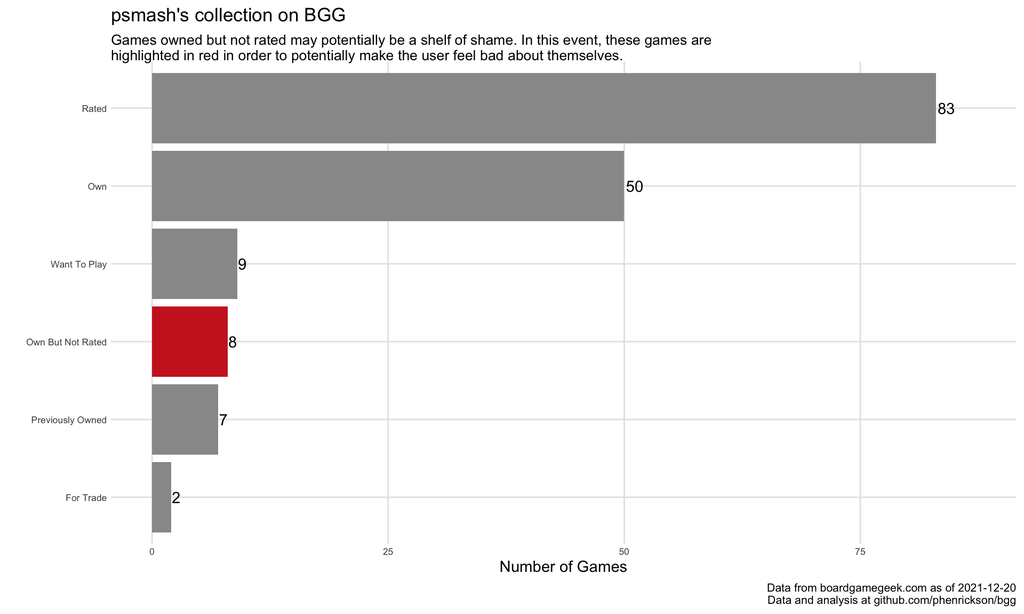

What years has the user owned/rated games from? While we can’t see when a user added or removed a game from their collection, we can look at their collection by the years in which their games were published.

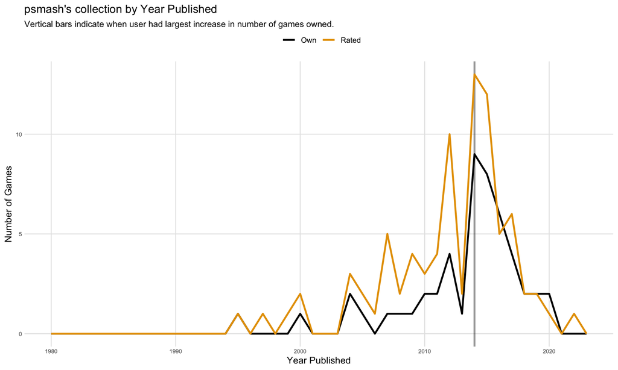

## 1.1 What types of games does psmash own?

We can look at the most frequent types of categories, mechanics, designers, and artists that appear in a user’s collection.

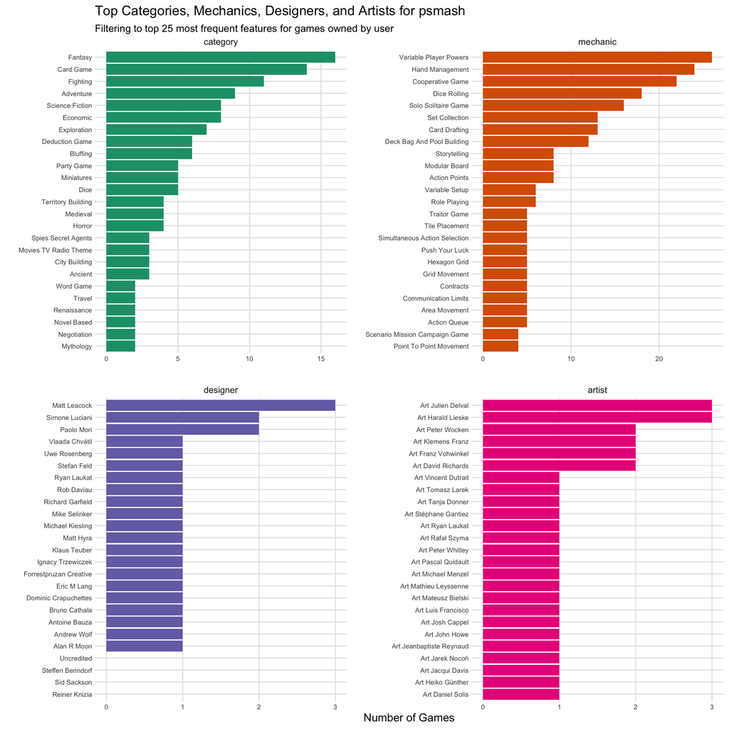

# 2 Modeling **psmash’s** Collection

| username | dataset | period | games_owned | games_rated | games_played |
| --- | --- | --- | --- | --- | --- |
| psmash | training | published before 2020 | 48 | 80 | 88 |
| psmash | test | published 2020 or later | 2 | 2 | 3 |

There are two main (binary) outcomes we will be modeling for the user.

The first, **own** refers to whether the user currently lists a game as owned in their collection. The second, **played** refers to whether the user currently owns, has rated, or previously owned a game. This means the latter will generally have a larger list of games, but may still be a useful category to examine for people who play lots of games without necessarily owning them.

We will train predictive models to learn the probability that the user will own or play individual games based on their features.

## 2.1 Coefficients for psmash

We can examine coefficients from the trained modes, which are penalized logistic regressions fit to our two main outcomes. Positive values indicate that a feature increases a user’s probabilility of owning/rating a game, while negative values indicate a feature decreases the probability.

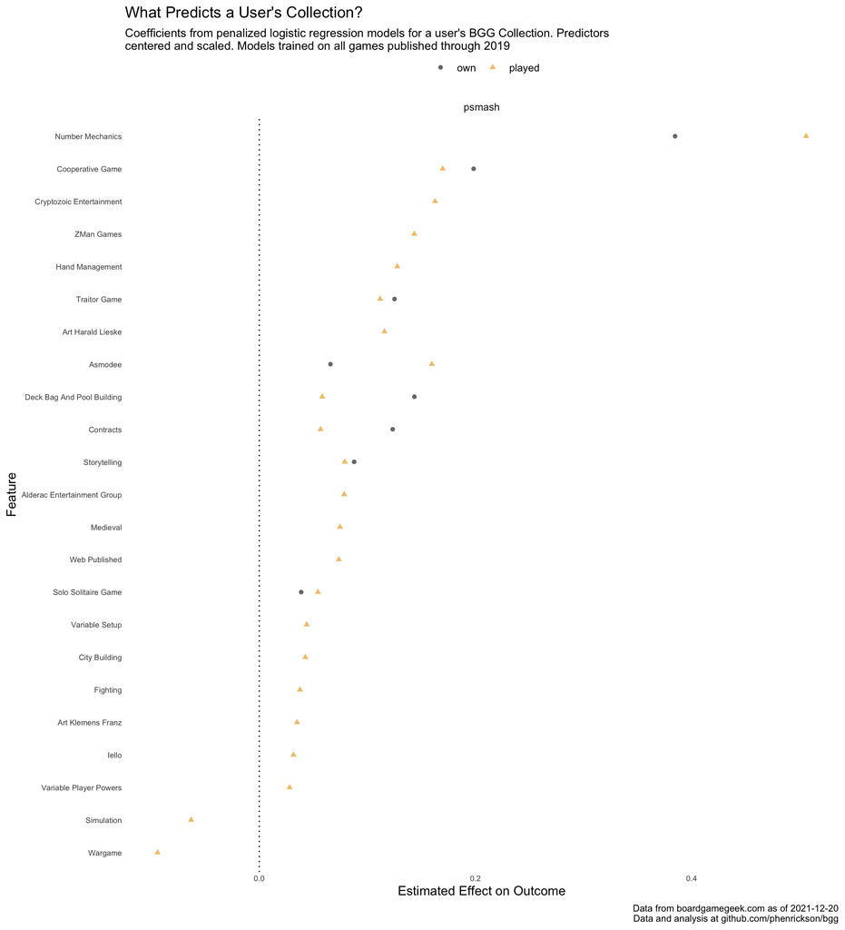

## 2.2 Visualizing Predictors for psmash’s Collection

Why did the model identify these features? We can make density plots of the important features for predicting whether the user owned a game. Blue indicates the density for games owned by the user, while grey indicates the density for games not owned by the user.

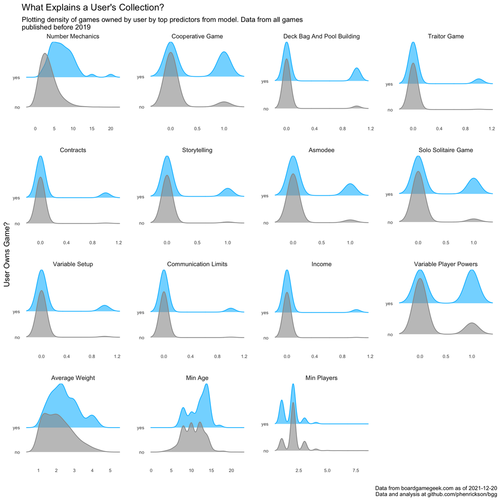

Binary predictors can be difficult to see with this visualization, so we can also directly examine the percentage of games in a user’s collection with a predictor vs the percentage of all games with that predictor.

| username | Feature | % of Games with Feature In_Collection | % of Games with Feature All_Games | Ratio |
| --- | --- | --- | --- | --- |
| psmash | Traitor Game | 10.4% | 0.6% | 16.7 |
| psmash | Contracts | 10.4% | 1.0% | 10.5 |
| psmash | Income | 6.2% | 0.7% | 8.9 |
| psmash | Communication Limits | 8.3% | 1.0% | 8.7 |
| psmash | Storytelling | 16.7% | 2.1% | 7.8 |
| psmash | Variable Setup | 12.5% | 1.8% | 6.8 |
| psmash | Deck Bag And Pool Building | 25.0% | 4.8% | 5.2 |
| psmash | Cooperative Game | 41.7% | 8.4% | 5.0 |
| psmash | Solo Solitaire Game | 29.2% | 5.8% | 5.0 |
| psmash | Asmodee | 22.9% | 5.3% | 4.3 |
| psmash | Variable Player Powers | 50.0% | 16.9% | 3.0 |
| psmash | Word Game | 4.2% | 1.8% | 2.4 |
| psmash | Horror | 8.3% | 3.9% | 2.1 |
| psmash | City Building | 6.2% | 4.3% | 1.5 |
| psmash | Medieval | 8.3% | 6.3% | 1.3 |
| psmash | Party Game | 10.4% | 8.5% | 1.2 |
| psmash | Negotiation | 4.2% | 3.7% | 1.1 |
| psmash | Trivia | 2.1% | 1.8% | 1.1 |
| psmash | Trains | 2.1% | 2.2% | 0.9 |
| psmash | Racing | 2.1% | 2.8% | 0.7 |
| psmash | Puzzle | 2.1% | 3.4% | 0.6 |
| psmash | Action Dexterity | 0.0% | 4.8% | 0.0 |
| psmash | Mafia | 0.0% | 0.7% | 0.0 |
| psmash | Prehistoric | 0.0% | 1.0% | 0.0 |
| psmash | Realtime | 0.0% | 4.2% | 0.0 |

# 3 Assess Model’s Performance on Training Set

Before predicting games in upcoming years, we can examine how well the model did and what games it liked in the training set. In this case, we used resampling techniques (cross validation) to ensure that the model had not seen a game before making its predictions.

## 3.1 Separation Plot

An easy way to examine the performance of classification model is to view a separation plot. We plot the predicted probabilities from the model for every game (from resampling) from lowest to highest. We then overlay a blue line for any game that the user does own. A good classifier is one that is able to *separate* the blue (games owned by the user) from the white (games not owned by the user), with most of the blue occurring at the highest probabilities (right side of the chart).

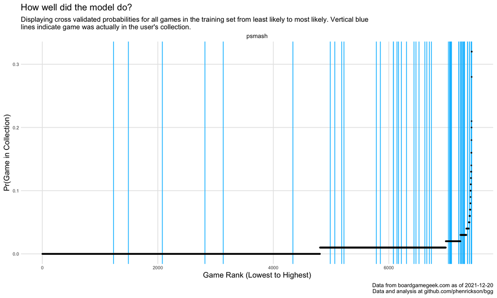

## 3.2 Top Games for **psmash** from Training Set

We can display this information in table form, displaying the 100 games with the highest probability of ownership, adding a blue line when the user does own the game.

| username | yearpublished | game_id | name | pred_played | pred_own | actual_played | actual_own |
| --- | --- | --- | --- | --- | --- | --- | --- |
| psmash | 2017 | 174430 | Gloomhaven | 0.76 | 0.32 | 1 | 1 |
| psmash | 2019 | 276025 | Maracaibo | 0.27 | 0.32 | 0 | 0 |
| psmash | 2005 | 15062 | Shadows over Camelot | 0.34 | 0.28 | 0 | 0 |
| psmash | 2018 | 240196 | Betrayal Legacy | 0.26 | 0.21 | 0 | 0 |
| psmash | 2019 | 264220 | Tainted Grail: The Fall of Avalon | 0.42 | 0.20 | 0 | 0 |
| psmash | 2017 | 228660 | Betrayal at Baldur's Gate | 0.20 | 0.18 | 0 | 0 |
| psmash | 2013 | 127024 | Room 25 | 0.26 | 0.16 | 0 | 0 |
| psmash | 2018 | 167355 | Nemesis | 0.13 | 0.16 | 0 | 0 |
| psmash | 2012 | 105551 | Archipelago | 0.31 | 0.14 | 0 | 0 |
| psmash | 2018 | 230769 | Who Goes There? | 0.08 | 0.13 | 0 | 0 |
| psmash | 2017 | 188920 | This War of Mine: The Board Game | 0.30 | 0.13 | 0 | 0 |
| psmash | 2014 | 150376 | Dead of Winter: A Crossroads Game | 0.11 | 0.13 | 1 | 1 |
| psmash | 2016 | 193037 | Dead of Winter: The Long Night | 0.17 | 0.13 | 1 | 1 |
| psmash | 2008 | 37111 | Battlestar Galactica: The Board Game | 0.24 | 0.12 | 0 | 0 |
| psmash | 2016 | 205059 | Mansions of Madness: Second Edition | 0.53 | 0.12 | 0 | 0 |
| psmash | 2018 | 244711 | Newton | 0.14 | 0.11 | 0 | 0 |
| psmash | 2004 | 9220 | Saboteur | 0.21 | 0.11 | 0 | 0 |
| psmash | 2018 | 170604 | Renegade | 0.15 | 0.11 | 0 | 0 |
| psmash | 2019 | 271754 | Spire's End | 0.13 | 0.10 | 0 | 0 |
| psmash | 2019 | 266507 | Clank!: Legacy – Acquisitions Incorporated | 0.13 | 0.10 | 0 | 0 |
| psmash | 2003 | 7240 | Vanished Planet | 0.03 | 0.10 | 0 | 0 |
| psmash | 2019 | 283863 | The Magnificent | 0.10 | 0.09 | 0 | 0 |
| psmash | 2018 | 192296 | The Pirate Republic | 0.17 | 0.08 | 0 | 0 |
| psmash | 2019 | 245655 | The King's Dilemma | 0.21 | 0.08 | 0 | 0 |
| psmash | 2019 | 169427 | Middara: Unintentional Malum – Act 1 | 0.15 | 0.07 | 0 | 0 |
| psmash | 2011 | 96848 | Mage Knight Board Game | 0.19 | 0.07 | 0 | 0 |
| psmash | 2014 | 146886 | La Granja | 0.13 | 0.07 | 0 | 0 |
| psmash | 2012 | 123096 | Space Cadets | 0.20 | 0.07 | 0 | 0 |
| psmash | 1986 | 925 | Werewolf | 0.11 | 0.07 | 0 | 0 |
| psmash | 2014 | 148949 | Istanbul | 0.05 | 0.07 | 0 | 0 |

[output cut: 70 more lines]

We can also more formally assess how well the model did in resampling by looking at the area under the receiver operating characteristic. A perfect model would receive a score of 1, while a model that cannot predict the outcome will default to a score of 0.5. The extent to which something is a *good* score depends on the setting, but generally anything in the .8 to .9 range is very good while the .7 to .8 range is perfectly acceptable.

| username | outcome_type | .metric | .estimator | .estimate |
| --- | --- | --- | --- | --- |
| psmash | own | roc_auc | binary | 0.855 |
| psmash | played | roc_auc | binary | 0.859 |

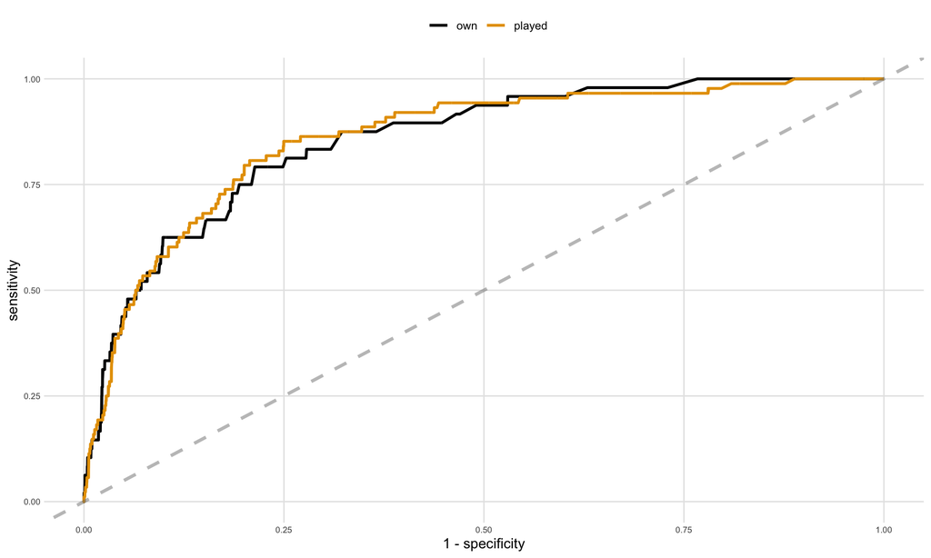

Another way to think about the model performance is to view its lift, or its ability to detect the positive outcomes over that of a null model. High lift indicates the model can much more quickly find all of the positive outcomes (in this case, games owned or played by the user), while a model with no lift is no better than random guessing.

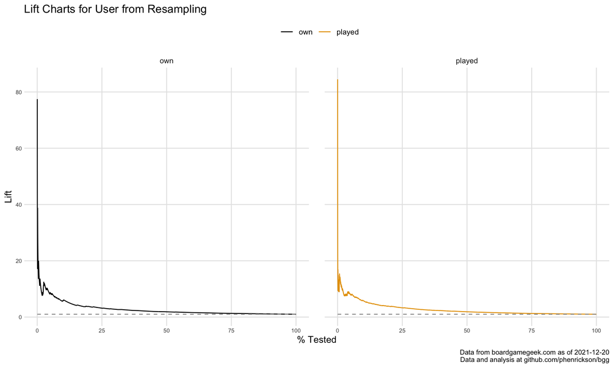

## 3.3 Most and Least Likely Games

What games does the model think psmash is **most likely to own** that are **not** in their collection?

| username | yearpublished | game_id | name | pred_own | actual_own |
| --- | --- | --- | --- | --- | --- |
| psmash | 2019 | 276025 | Maracaibo | 0.32 | 0 |
| psmash | 2005 | 15062 | Shadows over Camelot | 0.28 | 0 |
| psmash | 2018 | 240196 | Betrayal Legacy | 0.21 | 0 |
| psmash | 2019 | 264220 | Tainted Grail: The Fall of Avalon | 0.20 | 0 |
| psmash | 2017 | 228660 | Betrayal at Baldur's Gate | 0.18 | 0 |

What games does the model think psmash is **least likely to own** that **are** in their collection?

| username | yearpublished | game_id | name | pred_own | actual_own |
| --- | --- | --- | --- | --- | --- |
| psmash | 2015 | 179572 | Dice City | 0 | 1 |
| psmash | 2013 | 146816 | Sanssouci | 0 | 1 |
| psmash | 2000 | 2453 | Blokus | 0 | 1 |
| psmash | 2005 | 20100 | Wits & Wagers | 0 | 1 |
| psmash | 2017 | 206718 | Ethnos | 0 | 1 |

## 3.4 Top Games by Year

Top 25 games most likely to be owned by the user in each year, highlighting in blue the games that the user has owned/played.

| rank | 2011 | 2012 | 2013 | 2014 | 2015 | 2016 | 2017 | 2018 | 2019 |
| --- | --- | --- | --- | --- | --- | --- | --- | --- | --- |
| 1 | Mage Knight Board Game | Archipelago | Room 25 | Dead of Winter: A Crossroads Game | Discoveries: The Journals of Lewis & Clark | Dead of Winter: The Long Night | Gloomhaven | Betrayal Legacy | Maracaibo |
| 2 | Panic Station | Space Cadets | Forbidden Desert | La Granja | 504 | Mansions of Madness: Second Edition | Betrayal at Baldur's Gate | Nemesis | Tainted Grail: The Fall of Avalon |
| 3 | Flash Point: Fire Rescue | Robinson Crusoe: Adventures on the Cursed Island | Hoplomachus: Rise of Rome | Istanbul | T.I.M.E Stories | Aeon's End | This War of Mine: The Board Game | Who Goes There? | Spire's End |
| 4 | A Few Acres of Snow | One Night Werewolf | Pathfinder Adventure Card Game: Rise of the Runelords – Base Set | Pathfinder Adventure Card Game: Skull & Shackles – Base Set | Runebound (Third Edition) | Pathfinder Adventure Card Game: Mummy's Mask – Base Set | Century: Golem Edition | Newton | Clank!: Legacy – Acquisitions Incorporated |
| 5 | Gears of War: The Board Game | Descent: Journeys in the Dark (Second Edition) | Kashgar: Merchants of the Silk Road | Spurs: A Tale in the Old West | The Voyages of Marco Polo | Beyond Baker Street | Too Many Bones | Renegade | The Magnificent |
| 6 | Rune Age | Keyflower | Rory's Story Cubes: Prehistoria | Legendary Encounters: An Alien Deck Building Game | Salem 1692 | Burke's Gambit | The Thing: Infection at Outpost 31 | The Pirate Republic | The King's Dilemma |
| 7 | Takenoko | The Resistance: Avalon | Lewis & Clark: The Expedition | Ultimate Werewolf: Deluxe Edition | Homeland: The Game | The Oregon Trail Card Game | First Martians: Adventures on the Red Planet | Pax Emancipation | Middara: Unintentional Malum – Act 1 |
| 8 | Elder Sign | Lords of Waterdeep | The Ravens of Thri Sahashri | Deception: Murder in Hong Kong | Burgle Bros. | One Deck Dungeon | Spirit Island | Rising Sun | The Lord of the Rings: Journeys in Middle-Earth |
| 9 | Fortune and Glory: The Cliffhanger Game | Escape: The Curse of the Temple | City of Remnants | One Night Ultimate Werewolf | Far Space Foundry | Yokohama | Dark Souls: The Board Game | The City of Kings | Pandemic: Rapid Response |
| 10 | Rory's Story Cubes: Voyages | Agents of SMERSH | Train Heist | Roll for the Galaxy | One Night Ultimate Werewolf: Daybreak | Aventuria: Adventure Card Game | The 7th Continent | Dungeon Alliance | Obscurio |
| 11 | Eclipse | Mice and Mystics | Patchistory | Fields of Arle | Super Dungeon Explore: Forgotten King | Pandemic: Reign of Cthulhu | Breaking Bad: The Board Game | Realm of Sand | Call to Adventure |
| 12 | Dungeon Fighter | War of the Ring: Second Edition | Zpocalypse | Onirim (Second Edition) | March of the Ants | Secret Hitler | Summit: The Board Game | Star Realms: Frontiers | Era: Medieval Age |
| 13 | Star Trek Deck Building Game: The Next Generation | Wiz-War (Eighth Edition) | Eldritch Horror | Sons of Anarchy: Men of Mayhem | ...and then, we held hands. | Black Orchestra | One Deck Dungeon: Forest of Shadows | Century: Eastern Wonders | Last Bastion |
| 14 | Dungeons & Dragons: Wrath of Ashardalon Board Game | Freedom: The Underground Railroad | Rory's Story Cubes: Clues | Five Tribes | Die Legenden von Andor: Chada & Thorn | 13 Days: The Cuban Missile Crisis | Rescue Polar Bears: Data & Temperature | Big Trouble in Little China: The Game | Amul |
| 15 | Dungeons & Dragons: The Legend of Drizzt Board Game | Atlantis Rising | Super Fantasy: Ugly Snouts Assault | Shadowrun: Crossfire | Sylvion | Star Trek: The Dice Game | Sagrada | Street Masters | Horrified |
| 16 | Undermining | Zombicide | Impulse | Assault on Doomrock | Coffee Roaster | Star Trek: Frontiers | Tournament Fishing: The Deckbuilding Game | Warhammer Quest: Blackstone Fortress | Tapestry |
| 17 | Sekigahara: The Unification of Japan | Shadowrift | Bomb Squad | Splendor | Fireteam Zero | Mistfall: Heart of the Mists | Magic Maze | Too Many Bones: Undertow | Choose Your Own Adventure: War with the Evil Power Master |
| 18 | Fighting Formations: Grossdeutschland Motorized Infantry Division | Pax Porfiriana | Rococo | Outfoxed! | Steam Time | Warhammer Quest: Silver Tower | Dragonfire | Palm Island | Aeon's End: Legacy |
| 19 | No Retreat! The Russian Front | Mage Wars Arena | Concordia | Witness | Bastion | Mechs vs. Minions | Richard the Lionheart | Choose Your Own Adventure: House of Danger | Circadians: First Light |
| 20 | Space Infantry | Kingdom of Heaven: The Crusader States 1097-1291 | Band of Brothers: Ghost Panzer | Shadows of Malice | Kingdom Death: Monster | Expedition: The Roleplaying Card Game | Apocrypha Adventure Card Game: Box One – The World | The Order of Vampire Hunters | Pathfinder Adventure Card Game: Core Set |
| 21 | No Peace Without Spain!: The War of the Spanish Succession 1702-1713 | Targi | BattleLore: Second Edition | Stay Away! | Risk: Europe | Commissioned | Sub Terra | The Edge: Dawnfall | Cloudspire |
| 22 | Ascension: Return of the Fallen | For the Crown (Second Edition) | Crusade and Revolution: The Spanish Civil War, 1936-1939 | Ultimate Werewolf | Raiders of the North Sea | New Angeles | Unlock!: Escape Adventures – The Elite | Direwild | God of War: The Card Game |
| 23 | Drako: Dragon & Dwarves | 1989: Dawn of Freedom | Dungeon Twister: The Card Game | Warfighter: The Tactical Special Forces Card Game | XenoShyft: Onslaught | Time Bomb Evolution | Unlock!: Escape Adventures – Temple of Ra | Stuffed Fables | Sierra West |
| 24 | Field Commander: Napoleon | Nuklear Winter '68 | Smash Up: The Obligatory Cthulhu Set | Hyperborea | Thunderbirds | Pandemic: Iberia | Unlock!: Escape Adventures – Doo-Arann Dungeon | Holding On: The Troubled Life of Billy Kerr | Day Night Z |
| 25 | Friday | Neuroshima: Convoy | Batman: Arkham City Escape | Don't Mess with Cthulhu | Pandemic Legacy: Season 1 | Nautilion | Unlock!: Escape Adventures – Fifth Avenue | The Grizzled: Armistice Edition | Century: A New World |

## 3.5 Interactive Predictions from Resampling

Interactive table for predictions from resampling.

|  | username | yearpublished | rank | game_id | name | pred_played | pred_own | actual_played | actual_own |
| --- | --- | --- | --- | --- | --- | --- | --- | --- | --- |
| 1 | psmash | 1900 | 600 | 1602 | The Royal Game of Ur | 0.01 | 0.01 | 0 | 0 |
| 2 | psmash | 1900 | 704 | 10213 | Fox and Geese | 0.01 | 0.01 | 0 | 0 |
| 3 | psmash | 1900 | 2068 | 2136 | Pachisi | 0.01 | 0.01 | 0 | 0 |
| 4 | psmash | 1900 | 2069 | 2386 | Chinese Checkers | 0.01 | 0.01 | 0 | 0 |
| 5 | psmash | 1900 | 2147 | 2785 | Game of Goose | 0.01 | 0.01 | 0 | 0 |
| 6 | psmash | 1900 | 2643 | 5546 | Marbles | 0 | 0 | 0 | 0 |
| 7 | psmash | 1900 | 2646 | 11901 | Tic-Tac-Toe | 0 | 0 | 0 | 0 |
| 8 | psmash | 1900 | 2673 | 188 | Go | 0 | 0 | 0 | 0 |
| 9 | psmash | 1900 | 2746 | 171 | Chess | 0.01 | 0 | 0 | 0 |
| 10 | psmash | 1900 | 2754 | 2065 | Shogi | 0 | 0 | 0 | 0 |

[output cut: 7426 more lines]

# 4 Validating the Model on 2020

How well did a model trained on a user’s collection through 2019 perform in predicting games for the user from 2020?

| username | outcome_type | yearpublished | .metric | .estimator | .estimate |
| --- | --- | --- | --- | --- | --- |
| psmash | own | 2020 | roc_auc | binary | 0.931 |
| psmash | played | 2020 | roc_auc | binary | 0.956 |

Table of top 25 games from 2020, highlighting games that the user owns.

| username | yearpublished | game_id | name | pred_own | pred_played | actual_own | actual_played |
| --- | --- | --- | --- | --- | --- | --- | --- |
| psmash | 2020 | 291457 | Gloomhaven: Jaws of the Lion | 0.13 | 0.47 | 1 | 1 |
| psmash | 2020 | 184267 | On Mars | 0.12 | 0.24 | 0 | 0 |
| psmash | 2020 | 262274 | D6: Dungeons, Dudes, Dames, Danger, Dice and Dragons! | 0.12 | 0.13 | 0 | 0 |
| psmash | 2020 | 304434 | Victim: The Cursed Forest | 0.10 | 0.15 | 0 | 0 |
| psmash | 2020 | 256317 | Guild Master | 0.07 | 0.17 | 0 | 0 |
| psmash | 2020 | 302809 | Betrayal at Mystery Mansion | 0.07 | 0.09 | 0 | 0 |
| psmash | 2020 | 280794 | Etherfields | 0.06 | 0.06 | 0 | 0 |
| psmash | 2020 | 292333 | Cowboys II: Cowboys & Indians Edition | 0.06 | 0.21 | 0 | 0 |
| psmash | 2020 | 296892 | Sacred Rites | 0.06 | 0.07 | 0 | 0 |
| psmash | 2020 | 300322 | Hallertau | 0.06 | 0.10 | 0 | 0 |
| psmash | 2020 | 284742 | Honey Buzz | 0.05 | 0.05 | 0 | 0 |
| psmash | 2020 | 257145 | Teenage Mutant Ninja Turtles Adventures: City Fall | 0.04 | 0.06 | 0 | 0 |
| psmash | 2020 | 282922 | Windward | 0.04 | 0.11 | 0 | 0 |
| psmash | 2020 | 289939 | Goblin Teeth | 0.04 | 0.04 | 0 | 0 |
| psmash | 2020 | 298352 | The Shining | 0.04 | 0.05 | 0 | 0 |
| psmash | 2020 | 306040 | Merv: The Heart of the Silk Road | 0.04 | 0.07 | 0 | 0 |
| psmash | 2020 | 307191 | Four against the Great Old Ones | 0.04 | 0.07 | 0 | 0 |
| psmash | 2020 | 316412 | The LOOP | 0.04 | 0.05 | 0 | 0 |
| psmash | 2020 | 273703 | Altar Quest | 0.03 | 0.05 | 0 | 0 |
| psmash | 2020 | 285972 | HEXplore It: The Sands of Shurax | 0.03 | 0.05 | 0 | 0 |
| psmash | 2020 | 294652 | By Stealth and Sea | 0.03 | 0.04 | 0 | 0 |
| psmash | 2020 | 299179 | Chancellorsville 1863 | 0.03 | 0.06 | 0 | 0 |
| psmash | 2020 | 300531 | Paleo | 0.03 | 0.08 | 0 | 0 |
| psmash | 2020 | 301767 | Mysterium Park | 0.03 | 0.05 | 0 | 0 |
| psmash | 2020 | 301880 | Raiders of Scythia | 0.03 | 0.04 | 0 | 0 |

# 5 Predicting Upcoming Games (2020 and On) for **psmash**

Examine the top games for the test set.

| username | yearpublished | game_id | name | rank | own | played |
| --- | --- | --- | --- | --- | --- | --- |
| psmash | 2020 | 291457 | Gloomhaven: Jaws of the Lion | 1 | 0.13 | 0.47 |
| psmash | 2020 | 262274 | D6: Dungeons, Dudes, Dames, Danger, Dice and Dragons! | 2 | 0.12 | 0.13 |
| psmash | 2020 | 184267 | On Mars | 3 | 0.12 | 0.24 |
| psmash | 2020 | 304434 | Victim: The Cursed Forest | 4 | 0.10 | 0.15 |
| psmash | 2020 | 302809 | Betrayal at Mystery Mansion | 5 | 0.07 | 0.09 |
| psmash | 2020 | 256317 | Guild Master | 6 | 0.07 | 0.17 |
| psmash | 2020 | 300322 | Hallertau | 7 | 0.06 | 0.10 |
| psmash | 2020 | 292333 | Cowboys II: Cowboys & Indians Edition | 8 | 0.06 | 0.21 |
| psmash | 2020 | 296892 | Sacred Rites | 9 | 0.06 | 0.07 |
| psmash | 2020 | 280794 | Etherfields | 10 | 0.06 | 0.06 |
| psmash | 2020 | 284742 | Honey Buzz | 11 | 0.05 | 0.05 |
| psmash | 2020 | 307191 | Four against the Great Old Ones | 12 | 0.04 | 0.07 |
| psmash | 2020 | 316412 | The LOOP | 13 | 0.04 | 0.05 |
| psmash | 2020 | 306040 | Merv: The Heart of the Silk Road | 14 | 0.04 | 0.07 |
| psmash | 2020 | 289939 | Goblin Teeth | 15 | 0.04 | 0.04 |
| psmash | 2020 | 298352 | The Shining | 16 | 0.04 | 0.05 |
| psmash | 2020 | 282922 | Windward | 17 | 0.04 | 0.11 |
| psmash | 2020 | 257145 | Teenage Mutant Ninja Turtles Adventures: City Fall | 18 | 0.04 | 0.06 |
| psmash | 2020 | 299179 | Chancellorsville 1863 | 19 | 0.03 | 0.06 |
| psmash | 2020 | 308652 | Age of Dogfights: WW1 | 20 | 0.03 | 0.04 |
| psmash | 2020 | 325555 | Cantaloop: Book 1 – Breaking into Prison | 21 | 0.03 | 0.05 |
| psmash | 2020 | 332782 | Cantaloop: Prequel | 22 | 0.03 | 0.04 |
| psmash | 2020 | 315196 | Dungeons & Dragons: Adventure Begins | 23 | 0.03 | 0.07 |
| psmash | 2020 | 313817 | Hello Neighbor: The Secret Neighbor Party Game | 24 | 0.03 | 0.04 |
| psmash | 2020 | 294652 | By Stealth and Sea | 25 | 0.03 | 0.04 |
| psmash | 2021 | 251661 | Oathsworn: Into the Deepwood | 1 | 0.13 | 0.29 |
| psmash | 2021 | 291847 | Mantis Falls | 2 | 0.11 | 0.24 |
| psmash | 2021 | 318322 | Hidden Strike: American Revolution | 3 | 0.09 | 0.13 |
| psmash | 2021 | 343905 | Boonlake | 4 | 0.08 | 0.12 |
| psmash | 2021 | 310100 | Nemesis: Lockdown | 5 | 0.08 | 0.11 |
| psmash | 2021 | 273330 | Bloodborne: The Board Game | 6 | 0.07 | 0.12 |
| psmash | 2021 | 280984 | Ruins: Death Binder | 7 | 0.07 | 0.11 |
| psmash | 2021 | 298102 | Roll Camera!: The Filmmaking Board Game | 8 | 0.07 | 0.15 |
| psmash | 2021 | 249277 | Brazil: Imperial | 9 | 0.07 | 0.12 |
| psmash | 2021 | 340909 | Gloomholdin' | 10 | 0.06 | 0.21 |
| psmash | 2021 | 316287 | Quest | 11 | 0.05 | 0.10 |
| psmash | 2021 | 300217 | Merchants of the Dark Road | 12 | 0.05 | 0.04 |
| psmash | 2021 | 318474 | Who Goes There? 2nd Edition | 13 | 0.05 | 0.05 |
| psmash | 2021 | 340237 | Wonder Book | 14 | 0.05 | 0.13 |
| psmash | 2021 | 260524 | Beyond Humanity: Colonies | 15 | 0.05 | 0.08 |
| psmash | 2021 | 299566 | Batman: The Animated Series Adventures – Shadow of the Bat | 16 | 0.05 | 0.09 |
| psmash | 2021 | 340466 | Unfathomable | 17 | 0.04 | 0.10 |
| psmash | 2021 | 340677 | Bad Company | 18 | 0.04 | 0.04 |
| psmash | 2021 | 310873 | Carnegie | 19 | 0.04 | 0.10 |
| psmash | 2021 | 252752 | Genotype: A Mendelian Genetics Game | 20 | 0.04 | 0.03 |
| psmash | 2021 | 319792 | Fly-A-Way | 21 | 0.04 | 0.03 |
| psmash | 2021 | 291572 | Oath: Chronicles of Empire and Exile | 22 | 0.04 | 0.12 |
| psmash | 2021 | 313085 | Sleep Tight | 23 | 0.04 | 0.04 |
| psmash | 2021 | 260789 | Assassin's Creed: Brotherhood of Venice | 24 | 0.04 | 0.07 |
| psmash | 2021 | 295785 | Euthia: Torment of Resurrection | 25 | 0.04 | 0.15 |
| psmash | 2022 | 317511 | Tindaya | 1 | 0.29 | 0.51 |
| psmash | 2022 | 295770 | Frosthaven | 2 | 0.15 | 0.32 |
| psmash | 2022 | 322524 | Bardsung | 3 | 0.13 | 0.29 |
| psmash | 2022 | 331106 | The Witcher: Old World | 4 | 0.09 | 0.32 |
| psmash | 2022 | 273814 | Deliverance | 5 | 0.07 | 0.19 |
| psmash | 2022 | 283137 | Human Punishment: The Beginning | 6 | 0.07 | 0.16 |
| psmash | 2022 | 317321 | Darkest Dungeon: The Board Game | 7 | 0.05 | 0.11 |
| psmash | 2022 | 304051 | Creature Comforts | 8 | 0.05 | 0.05 |
| psmash | 2022 | 340325 | Vagrantsong | 9 | 0.05 | 0.09 |
| psmash | 2022 | 274471 | Malhya: Lands of Legends | 10 | 0.04 | 0.09 |
| psmash | 2022 | 256680 | Return to Dark Tower | 11 | 0.04 | 0.11 |
| psmash | 2022 | 311823 | Nova Aetas Renaissance | 12 | 0.04 | 0.07 |
| psmash | 2022 | 322289 | Darwin's Journey | 13 | 0.03 | 0.03 |
| psmash | 2022 | 305462 | The Age of Atlantis | 14 | 0.03 | 0.03 |
| psmash | 2022 | 252315 | The Everrain | 15 | 0.03 | 0.05 |
| psmash | 2022 | 277025 | Vampire: The Masquerade – CHAPTERS | 16 | 0.03 | 0.07 |
| psmash | 2022 | 284118 | Mechanical Beast | 17 | 0.02 | 0.02 |
| psmash | 2022 | 299106 | Fractal: Beyond the Void | 18 | 0.02 | 0.04 |
| psmash | 2022 | 338067 | 6: Siege – The Board Game | 19 | 0.02 | 0.04 |
| psmash | 2022 | 270871 | Agemonia | 20 | 0.02 | 0.02 |
| psmash | 2022 | 342444 | Black Rose Wars: Rebirth | 21 | 0.02 | 0.03 |
| psmash | 2022 | 311988 | Frostpunk: The Board Game | 22 | 0.02 | 0.03 |
| psmash | 2022 | 316915 | U.S.S. Freedom | 23 | 0.02 | 0.03 |
| psmash | 2022 | 336986 | Flamecraft | 24 | 0.02 | 0.02 |
| psmash | 2022 | 325494 | ISS Vanguard | 25 | 0.02 | 0.02 |

## 5.1 Interactive Table for Upcoming Games 2020 and On

|  | username | yearpublished | game_id | name | rank | own | played |
| --- | --- | --- | --- | --- | --- | --- | --- |
| 1 | psmash | 2022 | 317511 | Tindaya | 1 | 0.29 | 0.51 |
| 2 | psmash | 2022 | 295770 | Frosthaven | 2 | 0.15 | 0.32 |
| 3 | psmash | 2022 | 322524 | Bardsung | 3 | 0.13 | 0.29 |
| 4 | psmash | 2020 | 291457 | Gloomhaven: Jaws of the Lion | 4 | 0.13 | 0.47 |
| 5 | psmash | 2021 | 251661 | Oathsworn: Into the Deepwood | 5 | 0.13 | 0.29 |
| 6 | psmash | 2020 | 262274 | D6: Dungeons, Dudes, Dames, Danger, Dice and Dragons! | 6 | 0.12 | 0.13 |
| 7 | psmash | 2020 | 184267 | On Mars | 7 | 0.12 | 0.24 |
| 8 | psmash | 2021 | 291847 | Mantis Falls | 8 | 0.11 | 0.24 |
| 9 | psmash | 2020 | 304434 | Victim: The Cursed Forest | 9 | 0.1 | 0.15 |
| 10 | psmash | 2021 | 318322 | Hidden Strike: American Revolution | 10 | 0.09 | 0.13 |

[output cut: 1627 more lines]